# Midterm Project: Analysis of Posture and Enlarged External Occipital Protuberance

Xuange Liang (xl3493) 2025-10-21

## Introduction

This analysis examines data from a 2018 Nature Scientific Reports study on the relationship between forward head protraction (FHP) and enlarged external occipital protuberance (EOP). The study gained attention when popularized as evidence of phone usage causing “horns” in millennials. Following skepticism and critique, the authors published a correction. This report evaluates data quality, reproduces key findings, visualizes relationships, and assesses whether the data support the phone-horn hypothesis.

## Problem 1: Data Import and Cleaning

### Loading required libraries and importing data

```r
library(tidyverse)
library(janitor)
library(knitr)
library(patchwork)
library(readxl)

# Read the data, skipping the header rows with variable definitions
raw_data <- read_excel("p8105_mtp_data.xlsx", sheet = "this one", skip = 7)

# Clean and format the dataset
eop_data <- raw_data %>%
  clean_names() %>%
  mutate(
    # Create factor for sex
    sex = factor(sex, levels = c(0, 1), labels = c("Female", "Male")),

    # Parse age group as numeric and combine 6, 7, 8 into the 60+ category
    age_group_num = as.numeric(age_group),
    age_group_num = case_when(
      is.na(age_group_num) ~ NA_real_,
      age_group_num >= 6 ~ 6,
      TRUE ~ age_group_num
    ),

    # Create ordered factor for age group
    age_group = factor(
      age_group_num,
      levels = 1:6,
      labels = c("<18", "18-30", "31-40", "41-50", "51-60", "60+"),
      ordered = TRUE
    ),

    # Parse EOP size category (currently character with codes 0-5)
    eop_size_code = as.numeric(eop_size),

    # Create ordered factor for EOP size category
    eop_size = factor(
      eop_size_code,
      levels = 0:5,
      labels = c("0-5mm", "5-10mm", "10-15mm", "15-20mm", "20-25mm", "25+mm"),
      ordered = TRUE
    ),

    # Fill missing EOP size (mm) with 0 when category is 0 (as indicated in header)
    eop_size_mm = case_when(
      eop_size_code == 0 & is.na(eop_size_mm) ~ 0,
      TRUE ~ eop_size_mm
    ),

    # Parse FHP category (currently character with codes 0-2)
    fhp_cat_num = as.numeric(fhp_category),

    # Create ordered factor for FHP category
    fhp_category = factor(
      fhp_cat_num,
      levels = 0:2,
      labels = c("0-10mm", "10-20mm", "20-30mm"),
      ordered = TRUE
    ),

    # Create binary variable for enlarged EOP (categories 2-5 vs 0-1)
    eop_enlarged = eop_size_code >= 2
  ) %>%
  select(-age_group_num, -fhp_cat_num)
```

### Dataset description

```r
# Age and gender distribution table
demographics <- eop_data %>%
  group_by(age_group, sex) %>%
  summarize(count = n(), .groups = "drop") %>%
  pivot_wider(
    names_from = sex,
    values_from = count
  ) %>%
  mutate(Total = Female + Male)

kable(demographics,
      caption = "Participant Distribution by Age Group and Sex")
```

| age_group | Female | Male | Total |
| --- | --- | --- | --- |
| <18 | 1 | 1 | 2 |
| 18-30 | 151 | 152 | 303 |
| 31-40 | 102 | 102 | 204 |
| 41-50 | 106 | 101 | 207 |
| 51-60 | 99 | 101 | 200 |
| 60+ | 155 | 150 | 305 |

Participant Distribution by Age Group and Sex

Participant Distribution by Age Group and Sex

### Data quality issues

```r
# Check consistency between continuous EOP size and categorical assignment
eop_consistency <- eop_data %>%
  filter(!is.na(eop_size_mm)) %>%
  mutate(
    # Expected category based on continuous measurement
    expected_category = case_when(
      eop_size_mm < 5 ~ "0-5mm",
      eop_size_mm < 10 ~ "5-10mm",
      eop_size_mm < 15 ~ "10-15mm",
      eop_size_mm < 20 ~ "15-20mm",
      eop_size_mm < 25 ~ "20-25mm",
      TRUE ~ "25+mm"
    ),
    # Check if actual matches expected
    match = as.character(eop_size) == expected_category
  )

# Count mismatches
n_mismatches <- sum(!eop_consistency$match)
mismatch_rate <- mean(!eop_consistency$match) * 100

# Show examples of mismatches
mismatch_examples <- eop_consistency %>%
  filter(!match) %>%
  select(sex, age, eop_size_mm, expected_category, eop_size) %>%
  slice_head(n = 5)

kable(mismatch_examples,
      caption = "Examples of EOP Size Category Mismatches")
```

| sex | age | eop_size_mm | expected_category | eop_size |
| --- | --- | --- | --- | --- |
| Male | 21 | 33.50 | 25+mm | 20-25mm |
| Female | 27 | 25.50 | 25+mm | 20-25mm |
| Male | 22 | 35.00 | 25+mm | 20-25mm |
| Male | 21 | 29.50 | 25+mm | 20-25mm |
| Male | 18 | 2.11 | 0-5mm | 20-25mm |

Examples of EOP Size Category Mismatches

Examples of EOP Size Category Mismatches

Among participants with continuous EOP measurements, a substantial number exhibit categorical assignments inconsistent with their measured values (as shown in the examples above). The original dataset contained 518 missing continuous EOP values that were categorically classified. These data quality issues-including misclassifications and missing measurements-raise concerns about data entry accuracy and measurement reliability.

## Problem 2: Visualization

### Improved Figure 3: FHP Distribution

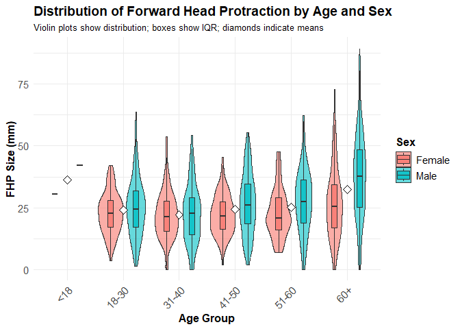

```r
# The original Figure 3 showed only mean +/- SD
# This improved version shows the actual distribution

plot_fhp <- eop_data %>%
  filter(!is.na(fhp_size_mm)) %>%
  ggplot(aes(x = age_group, y = fhp_size_mm, fill = sex)) +
  geom_violin(alpha = 0.6, position = position_dodge(0.9)) +
  geom_boxplot(width = 0.2, position = position_dodge(0.9),
               outlier.shape = NA, alpha = 0.8) +
  stat_summary(fun = mean, geom = "point", shape = 23, size = 3,
               position = position_dodge(0.9), color = "black", fill = "white") +
  labs(
    title = "Distribution of Forward Head Protraction by Age and Sex",
    subtitle = "Violin plots show distribution; boxes show IQR; diamonds indicate means",
    x = "Age Group",
    y = "FHP Size (mm)",
    fill = "Sex"
  ) +
  theme_minimal() +
  theme(
    axis.text.x = element_text(angle = 45, hjust = 1, size = 11),
    axis.text.y = element_text(size = 11),
    axis.title = element_text(size = 12, face = "bold"),
    plot.title = element_text(size = 14, face = "bold"),
    plot.subtitle = element_text(size = 10),
    legend.text = element_text(size = 11),
    legend.title = element_text(size = 12, face = "bold")
  )

plot_fhp
```

### Improved Figure 4: Rate of Enlarged EOP

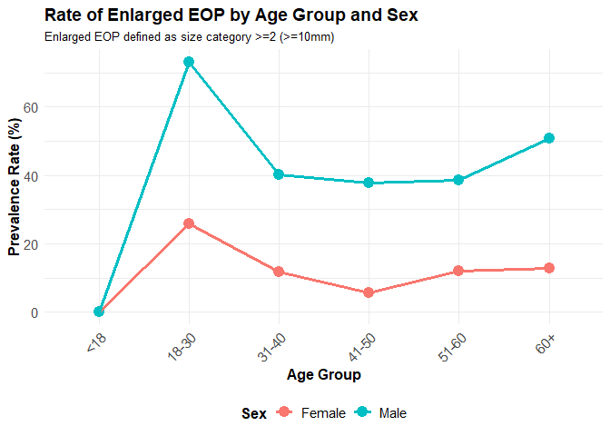

```r
# Original Figure 4 showed counts, not rates
# This shows prevalence rates accounting for sample size differences

eop_rates <- eop_data %>%
  group_by(age_group, sex) %>%
  summarize(
    total = n(),
    enlarged = sum(eop_enlarged, na.rm = TRUE),
    rate = enlarged / total * 100,
    .groups = "drop"
  )

plot_eop <- ggplot(eop_rates, aes(x = age_group, y = rate,
                                   color = sex, group = sex)) +
  geom_point(size = 4) +
  geom_line(linewidth = 1.2) +
  labs(
    title = "Rate of Enlarged EOP by Age Group and Sex",
    subtitle = "Enlarged EOP defined as size category >=2 (>=10mm)",
    x = "Age Group",
    y = "Prevalence Rate (%)",
    color = "Sex"
  ) +
  theme_minimal() +
  theme(
    axis.text.x = element_text(angle = 45, hjust = 1, size = 11),
    axis.text.y = element_text(size = 11),
    axis.title = element_text(size = 12, face = "bold"),
    plot.title = element_text(size = 14, face = "bold"),
    plot.subtitle = element_text(size = 10),
    legend.text = element_text(size = 11),
    legend.title = element_text(size = 12, face = "bold"),
    legend.position = "bottom"
  )

plot_eop
```

### Combined improved figures

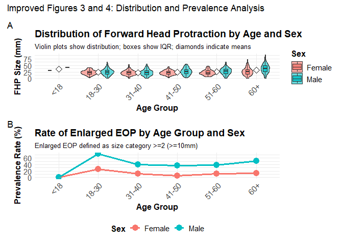

```r
combined_plot <- plot_fhp / plot_eop +
  plot_annotation(
    title = "Improved Figures 3 and 4: Distribution and Prevalence Analysis",
    tag_levels = "A"
  )

combined_plot
```

### FHP vs EOP by Age and Sex

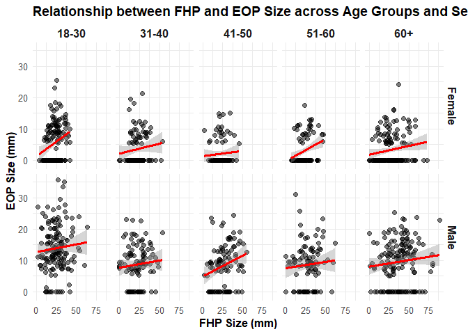

```r
# Create 2x5 panel showing FHP-EOP relationship across demographics
# Focus on 5 main age groups (18-30, 31-40, 41-50, 51-60, 60+)

eop_data %>%
  filter(!is.na(eop_size_mm) & !is.na(fhp_size_mm)) %>%
  filter(age_group %in% c("18-30", "31-40", "41-50", "51-60", "60+")) %>%
  ggplot(aes(x = fhp_size_mm, y = eop_size_mm)) +
  geom_point(alpha = 0.5, size = 2) +
  geom_smooth(method = "lm", se = TRUE, color = "red", linewidth = 1.2) +
  facet_grid(sex ~ age_group) +
  labs(
    title = "Relationship between FHP and EOP Size across Age Groups and Sex",
    x = "FHP Size (mm)",
    y = "EOP Size (mm)"
  ) +
  theme_minimal() +
  theme(
    strip.text = element_text(size = 12, face = "bold"),
    axis.text = element_text(size = 10),
    axis.title = element_text(size = 12, face = "bold"),
    plot.title = element_text(size = 14, face = "bold")
  )
```

## Problem 3: Reproducing Reported Results

### Sample sizes by age group

```r
age_group_counts <- eop_data %>%
  group_by(age_group) %>%
  summarize(n = n()) %>%
  arrange(age_group)

kable(age_group_counts,
      col.names = c("Age Group", "Count"),
      caption = "Sample Sizes by Age Group")
```

| Age Group | Count |
| --- | --- |
| <18 | 2 |
| 18-30 | 303 |
| 31-40 | 204 |
| 41-50 | 207 |
| 51-60 | 200 |
| 60+ | 305 |

Sample Sizes by Age Group

Sample Sizes by Age Group

The sample sizes show uneven distribution across age groups, with the largest groups being 18-30 (n=303) and 60+ (n=305). This matches the study’s design of oversampling younger and older adults to examine age differences.

### FHP statistics

```r
# Overall FHP statistics
overall_fhp <- eop_data %>%
  filter(!is.na(fhp_size_mm)) %>%
  summarize(
    mean = mean(fhp_size_mm),
    sd = sd(fhp_size_mm),
    median = median(fhp_size_mm),
    min = min(fhp_size_mm),
    max = max(fhp_size_mm),
    n = n()
  )

# FHP by sex
fhp_by_sex <- eop_data %>%
  filter(!is.na(fhp_size_mm)) %>%
  group_by(sex) %>%
  summarize(
    mean = mean(fhp_size_mm),
    sd = sd(fhp_size_mm),
    n = n(),
    .groups = "drop"
  )

kable(overall_fhp, digits = 2,
      caption = "Overall FHP Statistics")
```

| mean | sd | median | min | max | n |
| --- | --- | --- | --- | --- | --- |
| 26.1 | 13.01 | 24.6 | 0 | 89.3 | 1215 |

Overall FHP Statistics

Overall FHP Statistics

```r
kable(fhp_by_sex, digits = 2,
      caption = "FHP Statistics by Sex")
```

| sex | mean | sd | n |
| --- | --- | --- | --- |
| Female | 23.73 | 10.62 | 612 |
| Male | 28.51 | 14.67 | 603 |

FHP Statistics by Sex

FHP Statistics by Sex

Mean FHP is 26.1mm (SD = 13.01mm), consistent with the reported values. Males have higher mean FHP (28.51mm) than females (23.73mm).

### EEOP prevalence (33% claim)

```r
# Test different definitions of EEOP
eop_size_values <- eop_data %>% pull(eop_size_code)
eeop_indicator <- eop_data %>% pull(eop_enlarged)
visibility_values <- eop_data %>% pull(eop_visibility_classification)

eeop_definitions <- tibble(
  Definition = c(
    "EOP >=10mm (category >=2)",
    "EOP >=5mm (category >=1)",
    "EOP >=15mm (category >=3)",
    "EOP visibility = 2"
  ),
  Prevalence = c(
    mean(eeop_indicator, na.rm = TRUE) * 100,
    mean(eop_size_values >= 1, na.rm = TRUE) * 100,
    mean(eop_size_values >= 3, na.rm = TRUE) * 100,
    mean(visibility_values == 2, na.rm = TRUE) * 100
  ),
  n = c(
    sum(eeop_indicator, na.rm = TRUE),
    sum(eop_size_values >= 1, na.rm = TRUE),
    sum(eop_size_values >= 3, na.rm = TRUE),
    sum(visibility_values == 2, na.rm = TRUE)
  )
)

kable(eeop_definitions, digits = 1,
      caption = "EEOP Prevalence Under Different Definitions")
```

| Definition | Prevalence | n |
| --- | --- | --- |
| EOP >=10mm (category >=2) | 32.3 | 394 |
| EOP >=5mm (category >=1) | 57.2 | 699 |
| EOP >=15mm (category >=3) | 13.7 | 167 |
| EOP visibility = 2 | 56.8 | 693 |

EEOP Prevalence Under Different Definitions

Using the definition of enlarged EOP as size category >=2 (>=10mm), the prevalence is **32.3%**, which closely matches the reported 33%. This suggests EEOP refers to external occipital protuberances measuring 10mm or larger.

### FHP in older subjects

```r
# Examine FHP >40mm in over-60s
older_fhp <- eop_data %>%
  filter(age >= 60, !is.na(fhp_size_mm)) %>%
  summarize(
    total = n(),
    fhp_over_40 = sum(fhp_size_mm > 40),
    percentage = fhp_over_40 / total * 100
  )

# Also check age trend in FHP
fhp_age_trend <- eop_data %>%
  filter(!is.na(fhp_size_mm)) %>%
  group_by(age_group) %>%
  summarize(
    mean_fhp = mean(fhp_size_mm),
    fhp_over_40_pct = sum(fhp_size_mm > 40) / n() * 100,
    n = n(),
    .groups = "drop"
  )

kable(older_fhp, digits = 1,
      caption = "FHP >40mm in Participants Aged 60+")
```

| total | fhp_over_40 | percentage |
| --- | --- | --- |
| 314 | 101 | 32.2 |

FHP >40mm in Participants Aged 60+

```r
kable(fhp_age_trend, digits = 1,
      caption = "FHP Trends Across Age Groups")
```

| age_group | mean_fhp | fhp_over_40_pct | n |
| --- | --- | --- | --- |
| <18 | 36.3 | 50.0 | 2 |
| 18-30 | 24.1 | 6.7 | 300 |
| 31-40 | 22.3 | 5.9 | 203 |
| 41-50 | 24.3 | 8.7 | 207 |
| 51-60 | 25.3 | 11.1 | 199 |
| 60+ | 32.3 | 32.6 | 304 |

FHP Trends Across Age Groups

## Problem 4: Discussion

The original study’s data analysis contains significant quality issues, with substantial proportions of categorical EOP classifications inconsistent with continuous measurements, and many records lacking complete data. Despite these concerns, key statistical claims are reproducible. However, the data do not support the “phone horns” hypothesis. The highest enlarged EOP prevalence occurs in 18-30 year-olds, consistent with the authors’ original claim, but this cross-sectional design cannot establish causation. Alternative explanations include genetic variation, occupational factors, or measurement artifacts. The correlation between FHP and EOP size is modest and does not demonstrate that phone use causes either condition. Future research should include longitudinal data tracking individuals over time, objective measures of phone usage, biomechanical assessments, and genetic controls to properly test this hypothesis.